# `ciftiTools` Demo

Damon Pham & Amanda Mejia

2026-06-22

`ciftiTools` is an R package for working with CIFTI-2 format brain imaging data. Used in conjunction with GIFTI surface geometry files, CIFTI files enable surface-based analysis of gray matter data, which has several advantages over traditional volumetric/voxel-based analysis. Because of this, the CIFTI-2 format is used by recent neuroimaging studies including the Human Connectome Project (HCP). `ciftiTools` supports reading, writing, visualizing, resampling, and other operations for CIFTI files with the `".dscalar.nii"`, `".dtseries.nii"`, and `".dlabel.nii"` intents. Several of these operations are made possible by the [Connectome Workbench](https://www.humanconnectome.org/software/connectome-workbench).

To get started, the first time you use `ciftiTools`, install it from either CRAN with `install.packages()` or Github with `devtools::install_github()`. Here, we will use the CRAN version.

```r
# Check if package installed. If not, install it.
if(!require('ciftiTools', quietly=TRUE)){
  install.packages('ciftiTools')
  # devtools::install_github('mandymejia/ciftiTools') # development version
}
```

Now we load the `ciftiTools` package.

```r
library(ciftiTools)
```

Next, we indicate where to find the Connectome Workbench. This can be the full path to the Connectome Workbench executable file, or the path to its containing folder, in which case `ciftiTools` will locate the full path. Here, we will use the latter:

```r
# Replace '~/Desktop/workbench' with the actual path to
#   the Connectome Workbench folder on your computer.
#   If successful, the path to the Workbench executable will be printed.
ciftiTools.setOption('wb_path', '~/Applications')
```

```
## Using this Workbench path: '/Users/ddpham/Applications/workbench/bin_macosxub/wb_command'.
```

In this vignette, we will use example data included in the `ciftiTools` package. The files are originally from [NITRC](https://www.nitrc.org/frs/?group_id=454):

- The “MyelinAndCorrThickness” dtseries and dscalar files contain the same data: “MyelinMap_BC_decurv” and “corrThickness”. (A dtseries file usually contains fMRI BOLD timeseries data, but that would be too large to include in the package.)
- The dlabel file contains three cortical parcellations
- The “ones” dscalar file is the only file to include subcortical voxels. All its data values are 1.
- To reduce the size of `ciftiTools`, the dscalar and dlabel CIFTIs were resampled to 6k and the “ones” dscalar was resampled to 1k.

We will also use GIFTI files containing inflated surface geometry.

```r
cifti_fnames <- ciftiTools.files()$cifti
surfL_fname <- ciftiTools.files()$surf["left"]
surfR_fname <- ciftiTools.files()$surf["right"]
```

# Reading and Writing

### Reading

CIFTI files organize the gray matter of the brain into “grayordinates”: vertices representing the left and right cortical surfaces, and voxels representing the subcortical gray matter structures and the cerebellum. A CIFTI file consists of two parts: (1) an XML header which contains all the metadata including medial wall locations, subcortical structure labels, and the subcortical volumetric mask; and (2) a NIFTI format matrix representing all the grayordinate data. These components are read in together with `read_cifti`:

```r
basename(cifti_fnames["dtseries"])
```

```
## [1] "Conte69.MyelinAndCorrThickness.32k_fs_LR.dtseries.nii"
```

```r
xii <- read_xifti(cifti_fnames["dtseries"])
```

The result of `read_cifti` is a `"xifti"` object. We can get an overview of it using its `summary` S3 method:

```r
xii # same as `summary(xii)`
```

```
## ====CIFTI METADATA===================
## Intent:           3002 (dtseries)
## - time step       1 (seconds)
## - time start      0
## Measurements:     2 columns
##
## ====BRAIN STRUCTURES=================
## - left cortex     30424 data vertices
##                   2068 medial wall vertices (32492 total)
##
## - right cortex    30527 data vertices
##                   1965 medial wall vertices (32492 total)
```

By default, `read_cifti` will read-in all existing brainstructures. Set `brainstructures=c("left","right")`, for example, to read in just the left and right cortex data. The full set of choices for brainstructures is any combination of `"left"`, `"right"` and `"subcortical"`, `"all"` for all three, or `"existing"` (default).

`"xifti"` objects are lists with entries `data` (the grayordinate data matrix, separated by brainstructure), `surf` (surface geometry), and `meta` (metadata, most of which is from the NIFTI XML header). `surf` distinguishes a `"xifti"` from a CIFTI file: the left and right cortical surface geometries are not included in CIFTI files, so they must be read from separate surface GIFTI files (ending in `surf.gii`). The surface must be compatible: the number of vertices must be the same, and each vertex in the CIFTI data must correspond to the vertex location in the corresponding GIFTI surface file. In this way, a `"xifti"` represents a combination of a CIFTI file with compatible GIFTI files for the cortical mesh.

We can add GIFTI surface geometries with `add_surf`:

```r
xii <- add_surf(xii, surfL=surfL_fname, surfR=surfR_fname)
xii
```

```
## ====CIFTI METADATA===================
## Intent:           3002 (dtseries)
## - time step       1 (seconds)
## - time start      0
## Measurements:     2 columns
##
## ====BRAIN STRUCTURES=================
## - left cortex     30424 data vertices
##                   2068 medial wall vertices (32492 total)
##                   left surface geometry is present
##
## - right cortex    30527 data vertices
##                   1965 medial wall vertices (32492 total)
##                   right surface geometry is present
```

Alternatively, we could have provided the surface geometries at the outset of reading the CIFTI file:

```r
xii2 <- read_xifti(cifti_fnames["dtseries"], surfL_fname=surfL_fname, surfR_fname=surfR_fname)
all.equal(xii, xii2) # same result
```

```
## [1] TRUE
```

To only read the CIFTI header, use `info_cifti`. Let’s read the header of the dscalar file:

```r
xii_info <- ciftiTools::info_cifti(cifti_fnames["dscalar"])
str(xii_info, nchar.max=50) # shows header structure
```

```
## List of 3
##  $ cortex :List of 2
##   ..$ medial_wall_mask:List of 2
##   .. ..$ left : logi [1:5762] TRUE TRUE TRUE TRUE TRUE TRUE ...
##   .. ..$ right: logi [1:5762] TRUE TRUE TRUE TRUE TRUE TRUE ...
##   ..$ resamp_res      : NULL
##  $ subcort:List of 4
##   ..$ labels     : NULL
##   ..$ mask       : NULL
##   ..$ trans_mat  : NULL
##   ..$ trans_units: NULL
##  $ cifti  :List of 4
##   ..$ intent         : num 3006
##   ..$ brainstructures: chr [1:2] "left" "right"
##   ..$ names          : chr [1:2] "MyelinMap_BC_decurv" "corrThickness"
##   ..$ misc           :List of 4
##   .. ..$ ParentProvenance : chr "C:\\Users\\damon\\AppData\\Local\"| __truncated__
##   .. ..$ ProgramProvenance: chr "Connectome Workbench\nType: Comma"| __truncated__
##   .. ..$ Provenance       : chr "C:\\Users\\damon\\Desktop\\WORKBE"| __truncated__
##   .. ..$ WorkingDirectory : chr "C:/Users/damon/Desktop/ciftiTools/vignettes"
```

To read in only certain columns of a CIFTI file, use the `idx` argument:

```r
read_xifti(cifti_fnames["dtseries"], idx=2) # second column only
```

```
## ====CIFTI METADATA===================
## Intent:           3002 (dtseries)
## - time step       1 (seconds)
## - time start      0
## Measurements:     1 column
##
## ====BRAIN STRUCTURES=================
## - left cortex     30424 data vertices
##                   2068 medial wall vertices (32492 total)
##
## - right cortex    30527 data vertices
##                   1965 medial wall vertices (32492 total)
```

### Writing

When a `"xifti"` object is written to files, the CIFTI components are placed in a CIFTI file and the surface geometries, if any, are placed in GIFTI files.

```r
out_dir <- tempdir()

write_xifti(
  xii,
  file.path(out_dir, "my_cifti.dtseries.nii"),
  file.path(out_dir, "my_L.surf.gii"), file.path(out_dir, "my_R.surf.gii")
)
```

```
## Writing left cortex.
## Writing right cortex.
## Creating CIFTI file from separated components.
## Writing surface geometry GIFTI(s).
```

With `separate_cifti`, a CIFTI can be separated and written into its component parts: the cortical data can be written to GIFTI metric or label files, and the subcortical data can be written to a NIFTI file. In addition, any ROIs or labels will also be written to files. The files are automatically named unless a new file name is provided.

```r
# Use default names for everything except left cortex
separated_fnames = separate_cifti(
  cifti_fnames["dscalar_ones"], brainstructures="existing",
  cortexL_fname="my_left_cortex.func.gii", write_dir = out_dir
)
# Files written to `out_dir`, or current working dir. if not specified
basename(separated_fnames)
```

```
## [1] "ones_1k.my_left_cortex.func.gii" "ones_1k.sep.ROI_L.func.gii"
## [3] "ones_1k.sep.R.func.gii"          "ones_1k.sep.ROI_R.func.gii"
## [5] "ones_1k.sep.nii"                 "ones_1k.sep.labels.nii"
## [7] "ones_1k.sep.ROI.nii"
```

Separated files can be read into R with the `oro.nifti`, `RNifti`, and `gifti` packages, and combined into a `"xifti"` object with `as.xifti`.

# Visualization

The cortical plots in `ciftiTools` are made possible by the `rgl` package. To prepare the R Markdown document for knitting we need to do the following:

```r
library(rgl)
rgl::setupKnitr()

# Sometimes the first OpenGL window does not render properly.
rgl::open3d(); rgl::close3d()
```

```
## glX
##   1
```

```r
# Define function for rendering images, to use only if knitting.
is_knit <- knitr::is_html_output() || knitr::is_latex_output()
knit_pic <- function(dpi=200){
  pic <- tempfile(fileext=".png")
  rgl:::rgl.snapshot(pic)
  rgl::close3d()
  knitr::include_graphics(pic, dpi=dpi)
}

# These are also required.
library(manipulateWidget)
library(ggpubr)
```

Now let’s take a look!

### Surface visualization

`view_xifti_surface(xii)` displays the cortical data on the surface mesh. This function has several primary arguments:

- `color_mode` specifies the nature of the data values: `"sequential"`, `"qualitative"` and `"diverging"`. If it is not provided, a default mode that makes sense for the data will be used.
- `colors` specifies the color palette to use. If it is not provided, a default palette that makes sense for the `color_mode` is used.
- `idx` controls which column(s) to display.
- `widget` and `fname` control the output type. If `fname` is not provided, an interactive plot is created: by default, an OpenGL window if the length of `idx` is one, and an embedded HTML widget if the length of `idx` is greater than one. `widget` can be used to override this default. On the other hand, if `fname` is provided, static image files (png) for each `idx` are created, unless `fname` ends in `.html` in which case an interactive html file will be saved. Lastly, both OpenGL windows and HTML widgets can be embedded in R Markdown documents for knitting; refer to the source code of this vignette to see how this works.
- `surfL` and `surfR` specify the surface geometry to plot the data on. If not provided, the surfaces in the `"xifti"` object is used. But if those are also unavailable, the “inflated” surfaces included in `ciftiTools` are used.

Let’s see an example using each `color_mode` option. Note how the included surfaces are used in the first plot, but if none are present as in the second and third plots, the default surfaces are automatically used for visualization. (In our case, the included surfaces *are* the default surfaces.) We’ll also make the second plot interactive by requesting display of two `idx`. Try clicking and dragging around the second plot to rotate, and scrolling to zoom in and out. Note that the first and third plots are OpenGL window snapshots, and that the second plot is an embedded HTML widget.

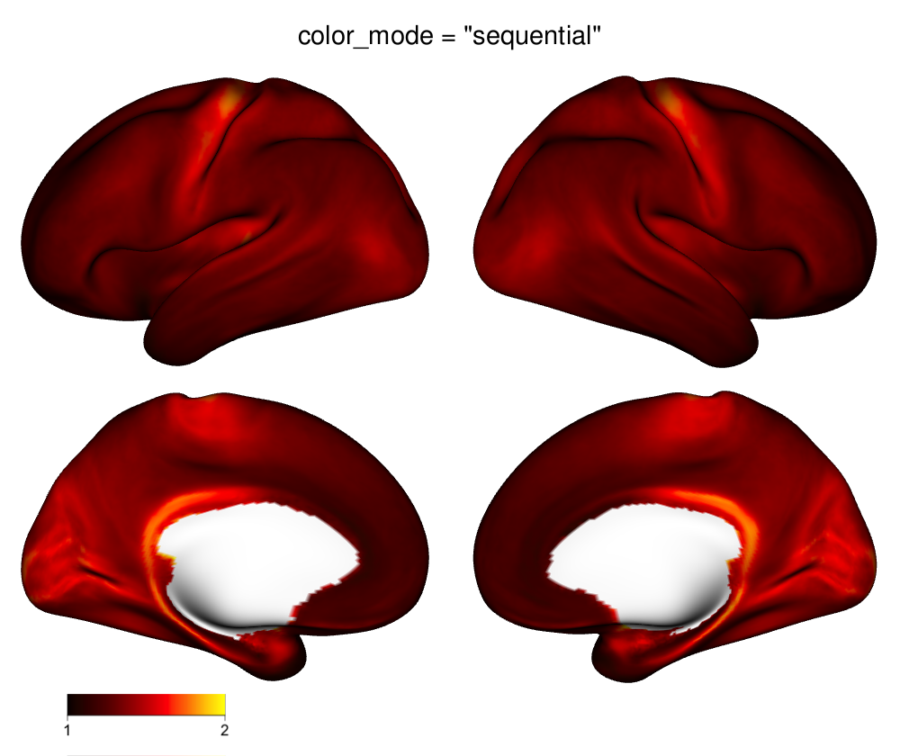

dtseries file; first column; sequential palette

```r
view_xifti_surface(xii, idx=1, zlim=c(1,2), title='color_mode = "sequential"')
if (is_knit) { knit_pic() }
```

```r
xii <- read_cifti(cifti_fnames["dscalar"]) # no GIFTI included, so the default inflated surface is used.
view_xifti_surface(
  xii, idx=1:2, zlim=c(0,5), color_mode = "diverging",
  title='color_mode = "diverging"'
)
```

[interactive chart not shown]

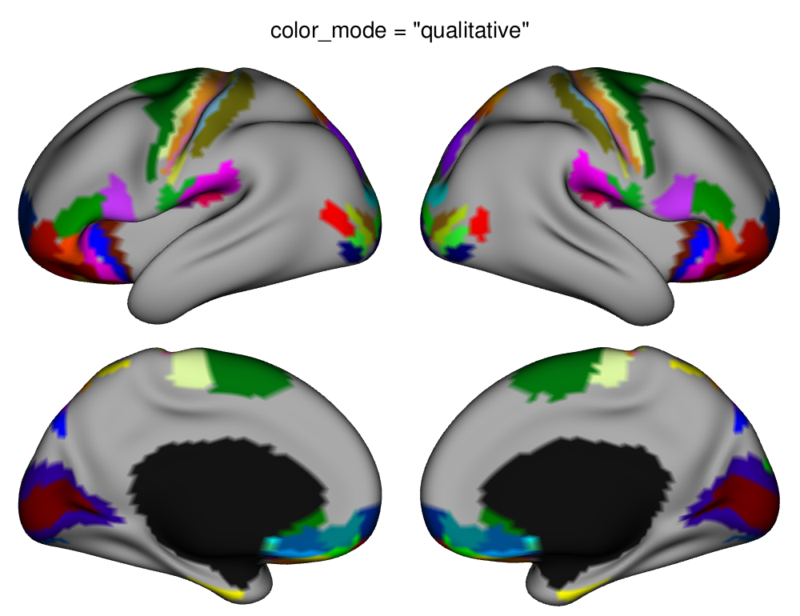

dlabel file; first label; palette from label metadata

```r
view_xifti_surface(
  read_cifti(cifti_fnames["dlabel"]),
  # Interactively, a color legend that displays the label names will also be printed.
  legend_ncol=5,
  title='color_mode = "qualitative"'
)
if (is_knit) { knit_pic() }
```

### Volume visualization

`view_xifti_volume(xii)` displays the subcortical data in slices. To view interactively in an interactive session, set `interactive=TRUE`. By default, a series of slices is displayed overlaid on the MNI template. The orientation and numbers of slices can be adjusted. A .png or .pdf file can be written with `fname`. The same color arguments from `view_xifti_surface` work too: `colors`, `color_mode` and `zlim`.

```r
# cifti_fnames["dscalar_ones"] is the only file with subcortical data
xii <- read_cifti(cifti_fnames["dscalar_ones"], brainstructures="subcortical")
view_xifti_volume(xii)
```

```
## `zlim` not provided: using color range 0 - 1 (data limits: 1 - 1).
```

```
## Selected axial slices: 9, 13, 17, 21, 25, 29, 33, 37, 41
```

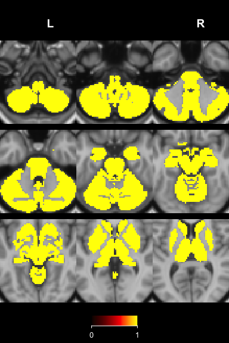

Subcortical data (all ones)

```r
# For information only, since papaya viewer cannot be embedded in knitted file
view_xifti_volume(xii, interactive = TRUE)
```

The S3 method `plot(xii)` will display all the data present in the `xifti` using `view_xifti_surface`, `view_xifti_volume`, or both. If both plots are made, the color mode and range will be shared between the two plots.

### Tips and tricks

`NA` values will be uncolored. You can use this to, for example, only color values meeting a certain threshold.

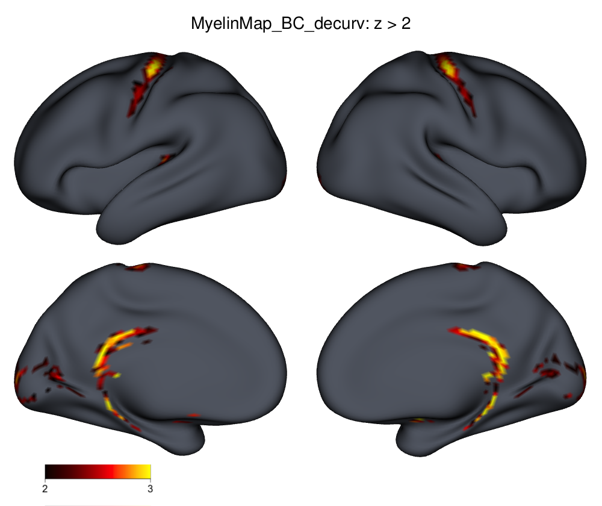

dscalar; using NA values to selectively color

```r
xii <- read_cifti(cifti_fnames["dscalar"])
# Convert to z-scores
xii <- scale_xifti(xii)
# Threshold
xii <- transform_xifti(xii, function(x){ifelse(x<2, NA, x)})
view_xifti_surface(
  xii, title='MyelinMap_BC_decurv: z > 2',
  zlim=c(2,3), NA_color="#505560"
)
if (is_knit) { knit_pic() }
```

Something to note is that the shadows from 3D rendering will darken colors in some folded regions of the brain. Another consideration is that the colors are smoothed continuously. In some situations, these default 3D shading properties may be undesirable. The `shadows` and `material` arguments can be used to adjust aspects of 3D shading.

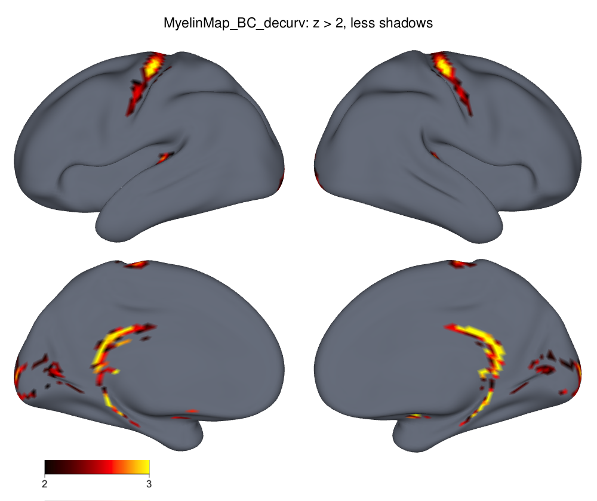

Lessening the shadows

```r
view_xifti_surface(
  xii, title='MyelinMap_BC_decurv: z > 2, less shadows',
  zlim=c(2,3), NA_color="#505560",
  shadows=0
)
if (is_knit) { knit_pic() }
```

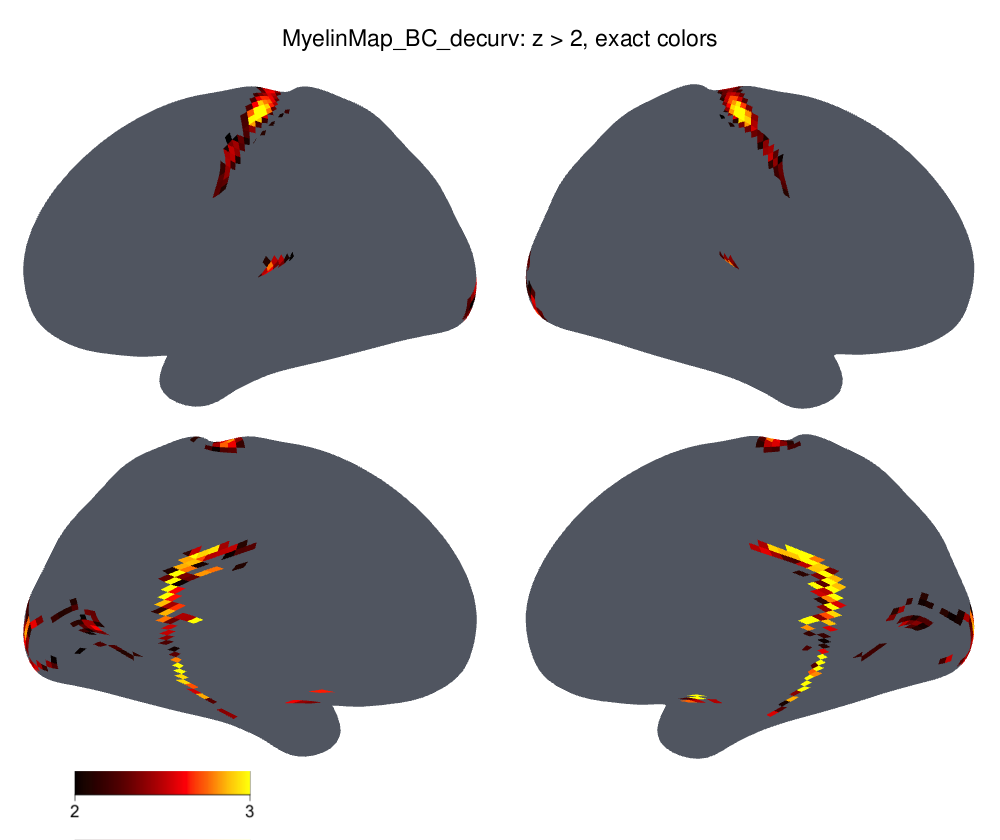

Exact coloring, by disabling shadows and color smoothing

```r
view_xifti_surface(
  xii, title='MyelinMap_BC_decurv: z > 2, exact colors',
  zlim=c(2,3), NA_color="#505560",
  material=list(lit=FALSE, smooth=FALSE)
)
if (is_knit) { knit_pic() }
```

# Resampling and smoothing

### Resampling

`ciftiTools` can resample CIFTI files to a lower resolution. Here, we resample the 32k dtseries file to 2k. (The number refers to the count of vertices on a single hemisphere.) We also provide the surfaces and resample them in conjunction.

```r
resampled_xii_fname <- "my_new_resampled.dtseries.nii"
resampled_surfL_fname <- "my_resampled_surfL.surf.gii"
resampled_surfR_fname <- "my_resampled_surfR.surf.gii"

xii_2k <- resample_cifti(
  cifti_fnames["dtseries"], resampled_xii_fname,
  resamp_res = 2000,
  surfL_fname, surfR_fname,
  resampled_surfL_fname, resampled_surfR_fname,
  write_dir = out_dir
)
```

```
## Separating CIFTI file.
## Time difference of 0.408498 secs
## Resampling CIFTI file.
## Time difference of 2.759915 secs
## Merging components into a CIFTI file...
## Time difference of 0.04207492 secs
```

```r
basename(xii_2k)
```

```
## [1] "my_new_resampled.dtseries.nii" "my_resampled_surfL.surf.gii"
## [3] "my_resampled_surfR.surf.gii"
```

Resampling can also be performed while reading a CIFTI file into R.

```r
read_cifti(cifti_fnames["dscalar"], resamp_res=2000)
```

```
## ====CIFTI METADATA===================
## Intent:           3006 (dscalar)
## - names           "MyelinMap_BC_decurv", "corrThickness"
## Measurements:     2 columns
##
## ====BRAIN STRUCTURES=================
## - left cortex     1856 data vertices
##                   106 medial wall vertices (1962 total)
##
## - right cortex    1863 data vertices
##                   99 medial wall vertices (1962 total)
```

### Smoothing

Use `smooth_cifti` to perform smoothing. Like resampling, this function works on both CIFTI files and `"xifti"` objects.

```r
smoothed_xii_fname <- "my_smoothed_cifti.dtseries.nii"

# Smoothing a CIFTI file
smooth_cifti(
  cifti_fnames["dtseries"], file.path(out_dir, smoothed_xii_fname),
  surf_FWHM=2, vol_FWHM=2,
  surfL_fname=surfL_fname, surfR_fname=surfR_fname,
  subcortical_zeroes_as_NA=TRUE
)
```

We’ll plot this smoothed CIFTI file with a diverging palette. Let’s try both the default pallete and an RColorBrewer palette.

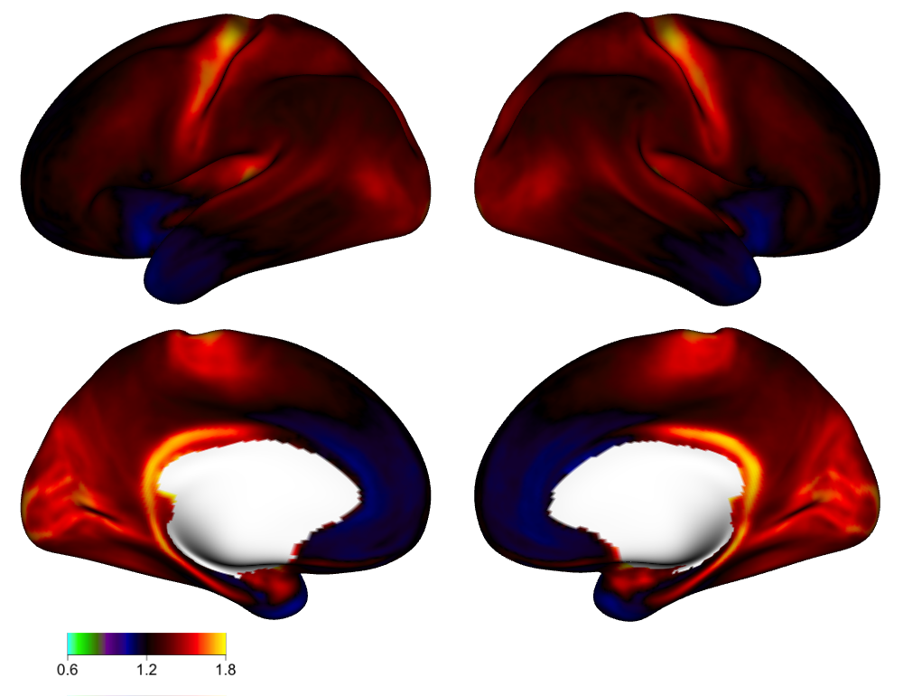

Smoothed CIFTI, default palette

```r
# Visualizing the smoothed file.
# Let's demonstrate the ability to use RColorBrewer palettes!
plot(
  read_cifti(file.path(out_dir, smoothed_xii_fname)),
  surfL=surfL_fname, surfR=surfR_fname,
  zlim=c(.6,1.8), color_mode="diverging"
)
if (is_knit) { knit_pic() }
```

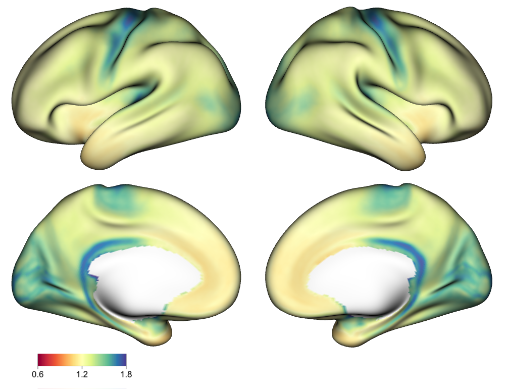

Smoothed CIFTI, RColorBrewer palette

```r
# Let's demonstrate the ability to use RColorBrewer palettes!
plot(
  read_cifti(file.path(out_dir, smoothed_xii_fname)),
  surfL=surfL_fname, surfR=surfR_fname,
  zlim=c(.6,1.8), color_mode="diverging", colors="Spectral"
)
if (is_knit) { knit_pic() }
```

# Manipulation & Math

You can treat the `"xifti"` as a data matrix with the base R functions `as.matrix`, `nrow`, and `ncol`.

```r
xiiL <- read_xifti(cifti_fnames["dscalar"], brainstructures="left")
dim(as.matrix(xiiL))
```

```
## [1] 5412    2
```

`apply_xifti` applies a function along the rows or columns of a `"xifti"`. The base R `apply` function also works on `"xifti"` objects. The difference is that when applying a function along the rows, the former will return a `"xifti"` whereas the latter will return a data matrix. For example, we can compute the mean at each data location like so:

```r
gmeans <- apply_xifti(xiiL, 1, mean)
gmeans
```

```
## ====CIFTI METADATA===================
## Intent:           3006 (dscalar)
## - names           "Column 1"
## Measurements:     1 column
##
## ====BRAIN STRUCTURES=================
## - left cortex     5412 data vertices
##                   350 medial wall vertices (5762 total)
```

And we can compute quantiles of each measurement like so:

```r
cquants <- apply_xifti(xiiL, 2, quantile, c(.1, .5)) # Quantiles of each column
cquants
```

```
##     MyelinMap_BC_decurv corrThickness
## 10%            1.178208      2.184971
## 50%            1.305912      2.766169
```

`combine_xifti` combines multiple `"xifti"`s with different brainstructures.

```r
xiiR <- read_xifti(cifti_fnames["dscalar"], brainstructures="right")
xii <- combine_xifti(xiiL, xiiR)
xii
```

```
## ====CIFTI METADATA===================
## Intent:           3006 (dscalar)
## - names           "MyelinMap_BC_decurv", "corrThickness"
## Measurements:     2 columns
##
## ====BRAIN STRUCTURES=================
## - left cortex     5412 data vertices
##                   350 medial wall vertices (5762 total)
##
## - right cortex    5434 data vertices
##                   328 medial wall vertices (5762 total)
```

`convert_xifti` converts the intent of a `"xifti"`.

```r
convert_xifti(xii, "dtseries") # Convert from dscalar to dtseries (don't use it)
```

```
## ====CIFTI METADATA===================
## Intent:           3002 (dtseries)
## - time step       1 (seconds)
## - time start      0
## Measurements:     2 columns
##
## ====BRAIN STRUCTURES=================
## - left cortex     5412 data vertices
##                   350 medial wall vertices (5762 total)
##
## - right cortex    5434 data vertices
##                   328 medial wall vertices (5762 total)
```

`merge_xifti` concatenates data matrices from multiple `"xifti"`s column-wise.

```r
xii <- merge_xifti(xii, xii) # Columns are repeated twice now.
```

`remove_xifti` removes a brainstructure(s) from a `"xifti"`.

```r
xii <- remove_xifti(xii, "cortex_left") # Now only the right cortex data is included.
xii
```

```
## ====CIFTI METADATA===================
## Intent:           3006 (dscalar)
## - names           "MyelinMap_BC_decurv", "corrThickness", "MyelinMap_BC_decurv", "corrThickness"
## Measurements:     4 columns
##
## ====BRAIN STRUCTURES=================
## - right cortex    5434 data vertices
##                   328 medial wall vertices (5762 total)
```

`select_xifti` subsets or re-orders the columns of the data matrix of a `"xifti"`.

```r
xii$meta$cifti$names <- paste("Column", seq(4))
xii <- select_xifti(xii, c(4,3,2)) # Reverse column order & drop the first.
xii
```

```
## ====CIFTI METADATA===================
## Intent:           3006 (dscalar)
## - names           "Column 4", "Column 3", "Column 2"
## Measurements:     3 columns
##
## ====BRAIN STRUCTURES=================
## - right cortex    5434 data vertices
##                   328 medial wall vertices (5762 total)
```

S3 methods allow for univariate transformations of `"xifti"` objects as well as arithmetic operations of multiple `"xifti"` objects.

```r
max(as.matrix(xii))
```

```
## [1] 4.63584
```

```r
xii <- 1 - exp(xii) / (xii * 2 + 3)
max(as.matrix(xii))
```

```
## [1] 0.4510765
```

# Working with surfaces

`ciftiTools` also includes functionality for working with surface geometry GIFTI files separately from any data. Surfaces that are read in are `"surf"` objects:

```r
# Reading
surf <- read_surf(surfL_fname)
surf
```

```
## Vertices:    32492
## Faces:       64980
## Hemisphere:  left
```

These can be written back to GIFTI files, visualized, and resampled. Resampling can be performed on the `"surf"` objects or the surface GIFTI files directly:

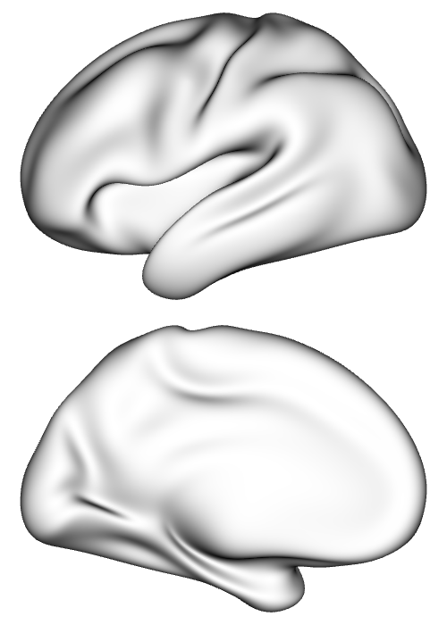

```r
# Writing
write_surf_gifti(surf, file.path(out_dir, "my.L.surf"))

# Visualizing
plot(surf)
if (is_knit) { knit_pic() }
```

```r
# Resample a `"surf"` object
surf <- resample_surf(surf, 2000, "left")
# Resample a GIFTI file
resample_gifti(surfL_fname, file.path(out_dir, "my.L.2k.surf.gii"), "left", resamp_res=2000)
```

As mentioned earlier, the inflated surface is included as a GIFTI file and can be accessed with `ciftiTools.files()`. It is used as default for visualizing data with `view_xifti_surface`. But two more surfaces are available through the function `load_surf`:

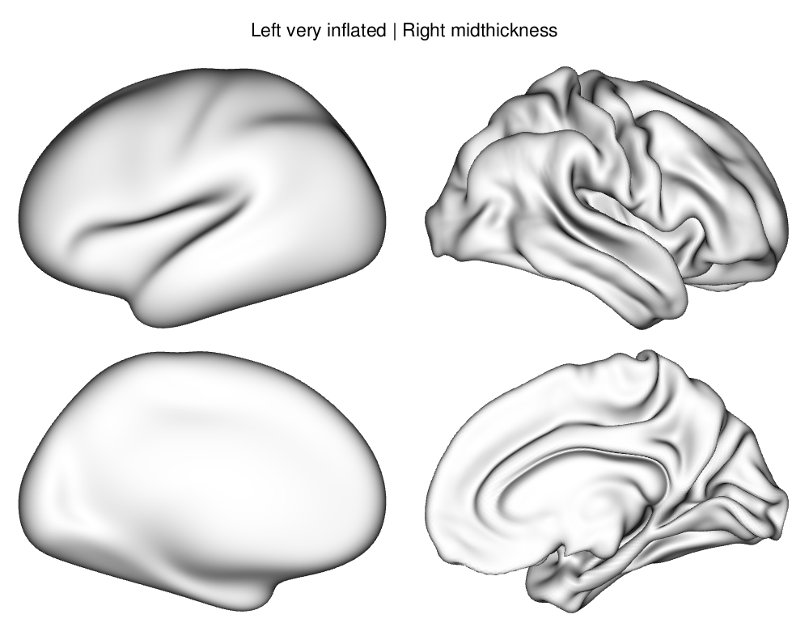

Two alternative surfaces

```r
xii <- as.xifti(
  surfL = load_surf("left", "very inflated"),
  surfR = load_surf("right", "midthickness")
)
plot(xii, title = "Left very inflated | Right midthickness")
if (is_knit) { knit_pic() }
```

Lastly, let’s demonstrate the ability to plot vertices and edges. (This can also be done when plotting `"xifti"` objects with data, using the same arguments.)

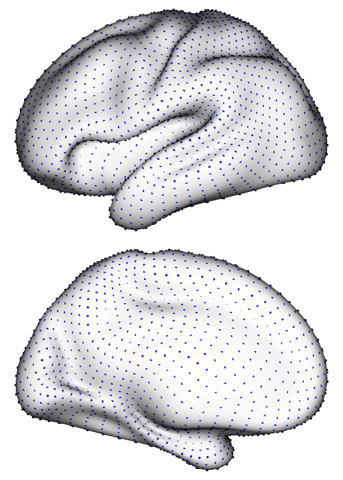

Surface with vertices drawn in blue

```r
# Recall that surf was resampled to 2k
plot(surf, vertex_size=3, vertex_color="blue")
if (is_knit) { knit_pic() }
```

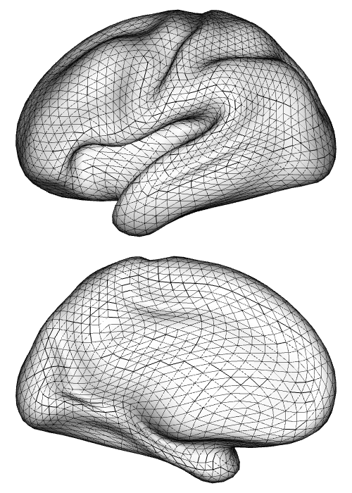

Surface with edges drawn in black

```r
plot(surf, edge_color="black")
if (is_knit) { knit_pic() }
```